# Risk Factor Analysis

## Outcome Variable

**Outcome Variable:** pers_wast

## Predictor Variables

**Intervention Variable:** perdiar6

**Adjustment Set:**

- arm
- sex
- W_mage
- meducyrs
- W_mhtcm
- W_mwtkg
- W_mbmi
- W_birthwt
- W_birthlen
- W_nrooms
- month
- brthmon
- impfloor
- impsan
- safeh20
- delta_W_mage
- delta_meducyrs
- delta_W_mhtcm
- delta_W_mwtkg
- delta_W_mbmi
- delta_W_birthwt
- delta_W_birthlen
- delta_W_nrooms
- delta_month
- delta_brthmon
- delta_impfloor
- delta_impsan
- delta_safeh20

## Stratifying Variables

The analysis was stratified on these variable(s):

- agecat
- studyid
- country

## Data Summary

| agecat | studyid | country | perdiar6 | pers_wast | n_cell | n |
| --- | --- | --- | --- | --- | --- | --- |
| 0-24 months | ki0047075b-MAL-ED | BANGLADESH | 0% | 0 | 69 | 248 |
| 0-24 months | ki0047075b-MAL-ED | BANGLADESH | 0% | 1 | 4 | 248 |
| 0-24 months | ki0047075b-MAL-ED | BANGLADESH | (0%, 5%] | 0 | 90 | 248 |
| 0-24 months | ki0047075b-MAL-ED | BANGLADESH | (0%, 5%] | 1 | 6 | 248 |
| 0-24 months | ki0047075b-MAL-ED | BANGLADESH | >5% | 0 | 76 | 248 |
| 0-24 months | ki0047075b-MAL-ED | BANGLADESH | >5% | 1 | 3 | 248 |
| 0-24 months | ki0047075b-MAL-ED | BRAZIL | 0% | 0 | 198 | 217 |
| 0-24 months | ki0047075b-MAL-ED | BRAZIL | 0% | 1 | 2 | 217 |
| 0-24 months | ki0047075b-MAL-ED | BRAZIL | (0%, 5%] | 0 | 15 | 217 |
| 0-24 months | ki0047075b-MAL-ED | BRAZIL | (0%, 5%] | 1 | 0 | 217 |
| 0-24 months | ki0047075b-MAL-ED | BRAZIL | >5% | 0 | 2 | 217 |
| 0-24 months | ki0047075b-MAL-ED | BRAZIL | >5% | 1 | 0 | 217 |
| 0-24 months | ki0047075b-MAL-ED | INDIA | 0% | 0 | 48 | 241 |
| 0-24 months | ki0047075b-MAL-ED | INDIA | 0% | 1 | 4 | 241 |
| 0-24 months | ki0047075b-MAL-ED | INDIA | (0%, 5%] | 0 | 118 | 241 |
| 0-24 months | ki0047075b-MAL-ED | INDIA | (0%, 5%] | 1 | 11 | 241 |
| 0-24 months | ki0047075b-MAL-ED | INDIA | >5% | 0 | 54 | 241 |
| 0-24 months | ki0047075b-MAL-ED | INDIA | >5% | 1 | 6 | 241 |
| 0-24 months | ki0047075b-MAL-ED | NEPAL | 0% | 0 | 78 | 238 |
| 0-24 months | ki0047075b-MAL-ED | NEPAL | 0% | 1 | 3 | 238 |
| 0-24 months | ki0047075b-MAL-ED | NEPAL | (0%, 5%] | 0 | 76 | 238 |
| 0-24 months | ki0047075b-MAL-ED | NEPAL | (0%, 5%] | 1 | 1 | 238 |
| 0-24 months | ki0047075b-MAL-ED | NEPAL | >5% | 0 | 80 | 238 |
| 0-24 months | ki0047075b-MAL-ED | NEPAL | >5% | 1 | 0 | 238 |
| 0-24 months | ki0047075b-MAL-ED | PERU | 0% | 0 | 71 | 284 |
| 0-24 months | ki0047075b-MAL-ED | PERU | 0% | 1 | 1 | 284 |
| 0-24 months | ki0047075b-MAL-ED | PERU | (0%, 5%] | 0 | 93 | 284 |
| 0-24 months | ki0047075b-MAL-ED | PERU | (0%, 5%] | 1 | 0 | 284 |
| 0-24 months | ki0047075b-MAL-ED | PERU | >5% | 0 | 119 | 284 |
| 0-24 months | ki0047075b-MAL-ED | PERU | >5% | 1 | 0 | 284 |

[output cut: 252 more lines]

The following strata were considered:

- agecat: 0-24 months, studyid: ki0047075b-MAL-ED, country: BANGLADESH
- agecat: 0-24 months, studyid: ki0047075b-MAL-ED, country: BRAZIL
- agecat: 0-24 months, studyid: ki0047075b-MAL-ED, country: INDIA
- agecat: 0-24 months, studyid: ki0047075b-MAL-ED, country: NEPAL
- agecat: 0-24 months, studyid: ki0047075b-MAL-ED, country: PERU
- agecat: 0-24 months, studyid: ki0047075b-MAL-ED, country: SOUTH AFRICA
- agecat: 0-24 months, studyid: ki0047075b-MAL-ED, country: TANZANIA, UNITED REPUBLIC OF
- agecat: 0-24 months, studyid: ki1000109-ResPak, country: PAKISTAN
- agecat: 0-24 months, studyid: ki1017093-NIH-Birth, country: BANGLADESH
- agecat: 0-24 months, studyid: ki1017093b-PROVIDE, country: BANGLADESH
- agecat: 0-24 months, studyid: ki1017093c-NIH-Crypto, country: BANGLADESH
- agecat: 0-24 months, studyid: ki1114097-CMIN, country: BANGLADESH
- agecat: 0-24 months, studyid: ki1114097-CMIN, country: BRAZIL
- agecat: 0-24 months, studyid: ki1114097-CMIN, country: GUINEA-BISSAU
- agecat: 0-24 months, studyid: ki1114097-CMIN, country: PERU
- agecat: 0-24 months, studyid: ki1114097-CONTENT, country: PERU
- agecat: 0-6 months, studyid: ki0047075b-MAL-ED, country: BANGLADESH
- agecat: 0-6 months, studyid: ki0047075b-MAL-ED, country: BRAZIL
- agecat: 0-6 months, studyid: ki0047075b-MAL-ED, country: INDIA
- agecat: 0-6 months, studyid: ki0047075b-MAL-ED, country: NEPAL
- agecat: 0-6 months, studyid: ki0047075b-MAL-ED, country: PERU
- agecat: 0-6 months, studyid: ki0047075b-MAL-ED, country: SOUTH AFRICA
- agecat: 0-6 months, studyid: ki0047075b-MAL-ED, country: TANZANIA, UNITED REPUBLIC OF
- agecat: 0-6 months, studyid: ki1000109-ResPak, country: PAKISTAN
- agecat: 0-6 months, studyid: ki1017093-NIH-Birth, country: BANGLADESH
- agecat: 0-6 months, studyid: ki1017093b-PROVIDE, country: BANGLADESH
- agecat: 0-6 months, studyid: ki1017093c-NIH-Crypto, country: BANGLADESH
- agecat: 0-6 months, studyid: ki1114097-CMIN, country: BANGLADESH
- agecat: 0-6 months, studyid: ki1114097-CMIN, country: GUINEA-BISSAU
- agecat: 0-6 months, studyid: ki1114097-CMIN, country: PERU
- agecat: 0-6 months, studyid: ki1114097-CONTENT, country: PERU
- agecat: 6-24 months, studyid: ki0047075b-MAL-ED, country: BANGLADESH
- agecat: 6-24 months, studyid: ki0047075b-MAL-ED, country: BRAZIL
- agecat: 6-24 months, studyid: ki0047075b-MAL-ED, country: INDIA
- agecat: 6-24 months, studyid: ki0047075b-MAL-ED, country: NEPAL
- agecat: 6-24 months, studyid: ki0047075b-MAL-ED, country: PERU
- agecat: 6-24 months, studyid: ki0047075b-MAL-ED, country: SOUTH AFRICA
- agecat: 6-24 months, studyid: ki0047075b-MAL-ED, country: TANZANIA, UNITED REPUBLIC OF
- agecat: 6-24 months, studyid: ki1000109-ResPak, country: PAKISTAN
- agecat: 6-24 months, studyid: ki1017093-NIH-Birth, country: BANGLADESH
- agecat: 6-24 months, studyid: ki1017093b-PROVIDE, country: BANGLADESH
- agecat: 6-24 months, studyid: ki1017093c-NIH-Crypto, country: BANGLADESH
- agecat: 6-24 months, studyid: ki1114097-CMIN, country: BANGLADESH
- agecat: 6-24 months, studyid: ki1114097-CMIN, country: BRAZIL
- agecat: 6-24 months, studyid: ki1114097-CMIN, country: GUINEA-BISSAU
- agecat: 6-24 months, studyid: ki1114097-CMIN, country: PERU
- agecat: 6-24 months, studyid: ki1114097-CONTENT, country: PERU

### Dropped Strata

Some strata were dropped due to rare outcomes:

- agecat: 0-24 months, studyid: ki0047075b-MAL-ED, country: BANGLADESH
- agecat: 0-24 months, studyid: ki0047075b-MAL-ED, country: BRAZIL
- agecat: 0-24 months, studyid: ki0047075b-MAL-ED, country: INDIA
- agecat: 0-24 months, studyid: ki0047075b-MAL-ED, country: NEPAL
- agecat: 0-24 months, studyid: ki0047075b-MAL-ED, country: PERU
- agecat: 0-24 months, studyid: ki0047075b-MAL-ED, country: SOUTH AFRICA
- agecat: 0-24 months, studyid: ki0047075b-MAL-ED, country: TANZANIA, UNITED REPUBLIC OF
- agecat: 0-24 months, studyid: ki1017093b-PROVIDE, country: BANGLADESH
- agecat: 0-24 months, studyid: ki1114097-CMIN, country: BRAZIL
- agecat: 0-24 months, studyid: ki1114097-CMIN, country: GUINEA-BISSAU
- agecat: 0-24 months, studyid: ki1114097-CMIN, country: PERU
- agecat: 0-24 months, studyid: ki1114097-CONTENT, country: PERU
- agecat: 0-6 months, studyid: ki0047075b-MAL-ED, country: BANGLADESH
- agecat: 0-6 months, studyid: ki0047075b-MAL-ED, country: BRAZIL
- agecat: 0-6 months, studyid: ki0047075b-MAL-ED, country: INDIA
- agecat: 0-6 months, studyid: ki0047075b-MAL-ED, country: NEPAL
- agecat: 0-6 months, studyid: ki0047075b-MAL-ED, country: PERU
- agecat: 0-6 months, studyid: ki0047075b-MAL-ED, country: SOUTH AFRICA
- agecat: 0-6 months, studyid: ki0047075b-MAL-ED, country: TANZANIA, UNITED REPUBLIC OF
- agecat: 0-6 months, studyid: ki1017093-NIH-Birth, country: BANGLADESH
- agecat: 0-6 months, studyid: ki1017093b-PROVIDE, country: BANGLADESH
- agecat: 0-6 months, studyid: ki1017093c-NIH-Crypto, country: BANGLADESH
- agecat: 0-6 months, studyid: ki1114097-CMIN, country: BANGLADESH
- agecat: 0-6 months, studyid: ki1114097-CMIN, country: GUINEA-BISSAU
- agecat: 0-6 months, studyid: ki1114097-CMIN, country: PERU
- agecat: 0-6 months, studyid: ki1114097-CONTENT, country: PERU
- agecat: 6-24 months, studyid: ki0047075b-MAL-ED, country: BANGLADESH
- agecat: 6-24 months, studyid: ki0047075b-MAL-ED, country: BRAZIL
- agecat: 6-24 months, studyid: ki0047075b-MAL-ED, country: INDIA
- agecat: 6-24 months, studyid: ki0047075b-MAL-ED, country: NEPAL
- agecat: 6-24 months, studyid: ki0047075b-MAL-ED, country: PERU
- agecat: 6-24 months, studyid: ki0047075b-MAL-ED, country: SOUTH AFRICA
- agecat: 6-24 months, studyid: ki0047075b-MAL-ED, country: TANZANIA, UNITED REPUBLIC OF
- agecat: 6-24 months, studyid: ki1017093b-PROVIDE, country: BANGLADESH
- agecat: 6-24 months, studyid: ki1114097-CMIN, country: BRAZIL
- agecat: 6-24 months, studyid: ki1114097-CMIN, country: GUINEA-BISSAU
- agecat: 6-24 months, studyid: ki1114097-CMIN, country: PERU
- agecat: 6-24 months, studyid: ki1114097-CONTENT, country: PERU

## Methods Detail

We’re interested in the causal parameters $E[Y_a]$ for all values of $a \in \mathcal{A}$. These parameters represent the mean outcome if, possibly contrary to fact, we intervened to set all units to have $A=a$. Under the randomization and positivity assumptions, these are identified by the statistical parameters $\psi_a=E_W[E_{Y|A,W}(Y|A=a,W)]$. In addition, we’re interested in the mean of $Y$, $E[Y]$ under no intervention (the observed mean). We will estimate these parameters by using SuperLearner to fit the relevant likelihood factors – $E_{Y|A,W}(Y|A=a,W)$ and $p(A=a|W)$, and then updating our likelihood fit using a joint TMLE.

For unadjusted analyses ($W=\{\}$), initial likelihoods were estimated using Lrnr_glm to estimate the simple $E(Y|A)$ and Lrnr_mean to estimate $p(A)$. For adjusted analyses, a small library containing Lrnr_glmnet, Lrnr_xgboost, and Lrnr_mean was used.

Having estimated these parameters, we will then use the delta method to estimate relative risks and attributable risks relative to a prespecified baseline level of $A$.

# Results Detail

## Results Plots

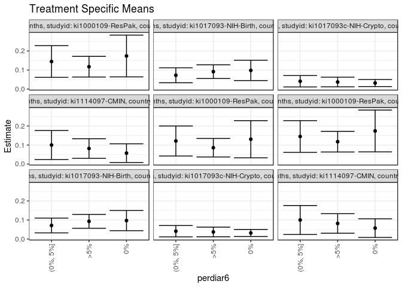

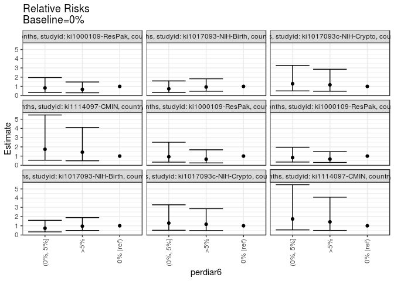

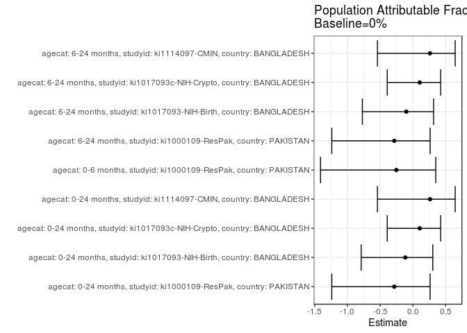

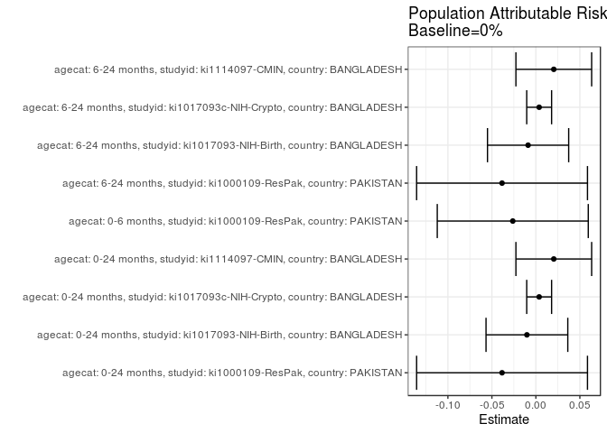

## Results Table

### Parameter: TSM

| agecat | studyid | country | intervention_level | baseline_level | estimate | ci_lower | ci_upper |
| --- | --- | --- | --- | --- | --- | --- | --- |
| 0-24 months | ki1000109-ResPak | PAKISTAN | 0% | NA | 0.1739130 | 0.0641604 | 0.2836657 |
| 0-24 months | ki1000109-ResPak | PAKISTAN | (0%, 5%] | NA | 0.1449275 | 0.0616999 | 0.2281551 |
| 0-24 months | ki1000109-ResPak | PAKISTAN | >5% | NA | 0.1176471 | 0.0633899 | 0.1719042 |
| 0-24 months | ki1017093-NIH-Birth | BANGLADESH | 0% | NA | 0.0982093 | 0.0447155 | 0.1517031 |
| 0-24 months | ki1017093-NIH-Birth | BANGLADESH | (0%, 5%] | NA | 0.0725536 | 0.0333385 | 0.1117687 |
| 0-24 months | ki1017093-NIH-Birth | BANGLADESH | >5% | NA | 0.0915322 | 0.0555635 | 0.1275009 |
| 0-24 months | ki1017093c-NIH-Crypto | BANGLADESH | 0% | NA | 0.0318841 | 0.0133322 | 0.0504359 |
| 0-24 months | ki1017093c-NIH-Crypto | BANGLADESH | (0%, 5%] | NA | 0.0411765 | 0.0112872 | 0.0710657 |
| 0-24 months | ki1017093c-NIH-Crypto | BANGLADESH | >5% | NA | 0.0372093 | 0.0118920 | 0.0625267 |
| 0-24 months | ki1114097-CMIN | BANGLADESH | 0% | NA | 0.0574713 | 0.0084700 | 0.1064726 |
| 0-24 months | ki1114097-CMIN | BANGLADESH | (0%, 5%] | NA | 0.1000000 | 0.0239428 | 0.1760572 |
| 0-24 months | ki1114097-CMIN | BANGLADESH | >5% | NA | 0.0818182 | 0.0304981 | 0.1331383 |
| 0-6 months | ki1000109-ResPak | PAKISTAN | 0% | NA | 0.1304348 | 0.0329081 | 0.2279615 |
| 0-6 months | ki1000109-ResPak | PAKISTAN | (0%, 5%] | NA | 0.1212121 | 0.0423083 | 0.2001159 |
| 0-6 months | ki1000109-ResPak | PAKISTAN | >5% | NA | 0.0859375 | 0.0372823 | 0.1345927 |
| 6-24 months | ki1000109-ResPak | PAKISTAN | 0% | NA | 0.1739130 | 0.0641604 | 0.2836657 |
| 6-24 months | ki1000109-ResPak | PAKISTAN | (0%, 5%] | NA | 0.1449275 | 0.0616999 | 0.2281551 |
| 6-24 months | ki1000109-ResPak | PAKISTAN | >5% | NA | 0.1176471 | 0.0633899 | 0.1719042 |
| 6-24 months | ki1017093-NIH-Birth | BANGLADESH | 0% | NA | 0.0968694 | 0.0437711 | 0.1499677 |
| 6-24 months | ki1017093-NIH-Birth | BANGLADESH | (0%, 5%] | NA | 0.0711443 | 0.0323430 | 0.1099456 |
| 6-24 months | ki1017093-NIH-Birth | BANGLADESH | >5% | NA | 0.0929279 | 0.0565227 | 0.1293331 |
| 6-24 months | ki1017093c-NIH-Crypto | BANGLADESH | 0% | NA | 0.0318841 | 0.0133322 | 0.0504359 |
| 6-24 months | ki1017093c-NIH-Crypto | BANGLADESH | (0%, 5%] | NA | 0.0411765 | 0.0112872 | 0.0710657 |
| 6-24 months | ki1017093c-NIH-Crypto | BANGLADESH | >5% | NA | 0.0372093 | 0.0118920 | 0.0625267 |
| 6-24 months | ki1114097-CMIN | BANGLADESH | 0% | NA | 0.0574713 | 0.0084700 | 0.1064726 |
| 6-24 months | ki1114097-CMIN | BANGLADESH | (0%, 5%] | NA | 0.1000000 | 0.0239428 | 0.1760572 |
| 6-24 months | ki1114097-CMIN | BANGLADESH | >5% | NA | 0.0818182 | 0.0304981 | 0.1331383 |

### Parameter: E(Y)

| agecat | studyid | country | intervention_level | baseline_level | estimate | ci_lower | ci_upper |
| --- | --- | --- | --- | --- | --- | --- | --- |
| 0-24 months | ki1000109-ResPak | PAKISTAN | NA | NA | 0.1354582 | 0.0930379 | 0.1778785 |
| 0-24 months | ki1017093-NIH-Birth | BANGLADESH | NA | NA | 0.0880150 | 0.0639627 | 0.1120673 |
| 0-24 months | ki1017093c-NIH-Crypto | BANGLADESH | NA | NA | 0.0356164 | 0.0221630 | 0.0490699 |
| 0-24 months | ki1114097-CMIN | BANGLADESH | NA | NA | 0.0778210 | 0.0450051 | 0.1106369 |
| 0-6 months | ki1000109-ResPak | PAKISTAN | NA | NA | 0.1041667 | 0.0654385 | 0.1428949 |
| 6-24 months | ki1000109-ResPak | PAKISTAN | NA | NA | 0.1354582 | 0.0930379 | 0.1778785 |
| 6-24 months | ki1017093-NIH-Birth | BANGLADESH | NA | NA | 0.0880150 | 0.0639627 | 0.1120673 |
| 6-24 months | ki1017093c-NIH-Crypto | BANGLADESH | NA | NA | 0.0356164 | 0.0221630 | 0.0490699 |
| 6-24 months | ki1114097-CMIN | BANGLADESH | NA | NA | 0.0778210 | 0.0450051 | 0.1106369 |

### Parameter: RR

| agecat | studyid | country | intervention_level | baseline_level | estimate | ci_lower | ci_upper |
| --- | --- | --- | --- | --- | --- | --- | --- |
| 0-24 months | ki1000109-ResPak | PAKISTAN | 0% | 0% | 1.0000000 | 1.0000000 | 1.000000 |
| 0-24 months | ki1000109-ResPak | PAKISTAN | (0%, 5%] | 0% | 0.8333333 | 0.3550213 | 1.956064 |
| 0-24 months | ki1000109-ResPak | PAKISTAN | >5% | 0% | 0.6764706 | 0.3095919 | 1.478115 |
| 0-24 months | ki1017093-NIH-Birth | BANGLADESH | 0% | 0% | 1.0000000 | 1.0000000 | 1.000000 |
| 0-24 months | ki1017093-NIH-Birth | BANGLADESH | (0%, 5%] | 0% | 0.7387647 | 0.3427736 | 1.592227 |
| 0-24 months | ki1017093-NIH-Birth | BANGLADESH | >5% | 0% | 0.9320116 | 0.4757550 | 1.825826 |
| 0-24 months | ki1017093c-NIH-Crypto | BANGLADESH | 0% | 0% | 1.0000000 | 1.0000000 | 1.000000 |
| 0-24 months | ki1017093c-NIH-Crypto | BANGLADESH | (0%, 5%] | 0% | 1.2914439 | 0.5093913 | 3.274157 |
| 0-24 months | ki1017093c-NIH-Crypto | BANGLADESH | >5% | 0% | 1.1670190 | 0.4767258 | 2.856848 |
| 0-24 months | ki1114097-CMIN | BANGLADESH | 0% | 0% | 1.0000000 | 1.0000000 | 1.000000 |
| 0-24 months | ki1114097-CMIN | BANGLADESH | (0%, 5%] | 0% | 1.7400000 | 0.5550642 | 5.454504 |
| 0-24 months | ki1114097-CMIN | BANGLADESH | >5% | 0% | 1.4236364 | 0.4939720 | 4.102946 |
| 0-6 months | ki1000109-ResPak | PAKISTAN | 0% | 0% | 1.0000000 | 1.0000000 | 1.000000 |
| 0-6 months | ki1000109-ResPak | PAKISTAN | (0%, 5%] | 0% | 0.9292929 | 0.3448322 | 2.504364 |
| 0-6 months | ki1000109-ResPak | PAKISTAN | >5% | 0% | 0.6588542 | 0.2579141 | 1.683075 |
| 6-24 months | ki1000109-ResPak | PAKISTAN | 0% | 0% | 1.0000000 | 1.0000000 | 1.000000 |
| 6-24 months | ki1000109-ResPak | PAKISTAN | (0%, 5%] | 0% | 0.8333333 | 0.3550213 | 1.956064 |
| 6-24 months | ki1000109-ResPak | PAKISTAN | >5% | 0% | 0.6764706 | 0.3095919 | 1.478115 |
| 6-24 months | ki1017093-NIH-Birth | BANGLADESH | 0% | 0% | 1.0000000 | 1.0000000 | 1.000000 |
| 6-24 months | ki1017093-NIH-Birth | BANGLADESH | (0%, 5%] | 0% | 0.7344348 | 0.3389404 | 1.591414 |
| 6-24 months | ki1017093-NIH-Birth | BANGLADESH | >5% | 0% | 0.9593112 | 0.4887916 | 1.882761 |
| 6-24 months | ki1017093c-NIH-Crypto | BANGLADESH | 0% | 0% | 1.0000000 | 1.0000000 | 1.000000 |
| 6-24 months | ki1017093c-NIH-Crypto | BANGLADESH | (0%, 5%] | 0% | 1.2914439 | 0.5093913 | 3.274157 |
| 6-24 months | ki1017093c-NIH-Crypto | BANGLADESH | >5% | 0% | 1.1670190 | 0.4767258 | 2.856848 |
| 6-24 months | ki1114097-CMIN | BANGLADESH | 0% | 0% | 1.0000000 | 1.0000000 | 1.000000 |
| 6-24 months | ki1114097-CMIN | BANGLADESH | (0%, 5%] | 0% | 1.7400000 | 0.5550642 | 5.454504 |
| 6-24 months | ki1114097-CMIN | BANGLADESH | >5% | 0% | 1.4236364 | 0.4939720 | 4.102946 |

### Parameter: PAR

| agecat | studyid | country | intervention_level | baseline_level | estimate | ci_lower | ci_upper |
| --- | --- | --- | --- | --- | --- | --- | --- |
| 0-24 months | ki1000109-ResPak | PAKISTAN | 0% | NA | -0.0384549 | -0.1355630 | 0.0586533 |
| 0-24 months | ki1017093-NIH-Birth | BANGLADESH | 0% | NA | -0.0101943 | -0.0566600 | 0.0362714 |
| 0-24 months | ki1017093c-NIH-Crypto | BANGLADESH | 0% | NA | 0.0037324 | -0.0104046 | 0.0178694 |
| 0-24 months | ki1114097-CMIN | BANGLADESH | 0% | NA | 0.0203497 | -0.0226891 | 0.0633886 |
| 0-6 months | ki1000109-ResPak | PAKISTAN | 0% | NA | -0.0262681 | -0.1120893 | 0.0595531 |
| 6-24 months | ki1000109-ResPak | PAKISTAN | 0% | NA | -0.0384549 | -0.1355630 | 0.0586533 |
| 6-24 months | ki1017093-NIH-Birth | BANGLADESH | 0% | NA | -0.0088544 | -0.0550014 | 0.0372925 |
| 6-24 months | ki1017093c-NIH-Crypto | BANGLADESH | 0% | NA | 0.0037324 | -0.0104046 | 0.0178694 |
| 6-24 months | ki1114097-CMIN | BANGLADESH | 0% | NA | 0.0203497 | -0.0226891 | 0.0633886 |

### Parameter: PAF

| agecat | studyid | country | intervention_level | baseline_level | estimate | ci_lower | ci_upper |
| --- | --- | --- | --- | --- | --- | --- | --- |
| 0-24 months | ki1000109-ResPak | PAKISTAN | 0% | NA | -0.2838875 | -1.2382452 | 0.2635449 |
| 0-24 months | ki1017093-NIH-Birth | BANGLADESH | 0% | NA | -0.1158249 | -0.7896128 | 0.3042824 |
| 0-24 months | ki1017093c-NIH-Crypto | BANGLADESH | 0% | NA | 0.1047938 | -0.3918344 | 0.4242173 |
| 0-24 months | ki1114097-CMIN | BANGLADESH | 0% | NA | 0.2614943 | -0.5412670 | 0.6461413 |
| 0-6 months | ki1000109-ResPak | PAKISTAN | 0% | NA | -0.2521739 | -1.4104582 | 0.3495264 |
| 6-24 months | ki1000109-ResPak | PAKISTAN | 0% | NA | -0.2838875 | -1.2382452 | 0.2635449 |
| 6-24 months | ki1017093-NIH-Birth | BANGLADESH | 0% | NA | -0.1006014 | -0.7711714 | 0.3160890 |
| 6-24 months | ki1017093c-NIH-Crypto | BANGLADESH | 0% | NA | 0.1047938 | -0.3918344 | 0.4242173 |
| 6-24 months | ki1114097-CMIN | BANGLADESH | 0% | NA | 0.2614943 | -0.5412670 | 0.6461413 |